# Investigating access to support centers for Violence Against Women in Apulia

2026-04-30

## Scope

- Modelling the **spatial** variability and the association with candidate **driving factors** in the **reporting** of **violence against women (VAW)**
- Variable of interest: **counts** of **accesses** to Anti-Violence Centers (AVCs) in **Apulia** per **residence municipality** of victims
- Observation period: **2021 – 2024**; observation units: **Apulian municipalities**.
- [Online version (**recursive**)](https://lcef97.github.io/CAV_Puglia/#1); more details [here](https://github.com/lcef97/CAV_Puglia/blob/main/CAV_panel.pdf)

## Importance of AVCs

- Offering **shelter**, **legal** assistance and **psycological** support to **women** victims of **gender-based violence**
- Maintaining systematic **records** of reported cases, as outlined in Italian Law no.119/2013
- Data collected by the Statistical Section and the Welfare Department of the Apulia **Region**, as part of a systematic **monitoring program** established under Regional Law no. 29/2014

## Access to AVCs in Apulia: Incidence (I)

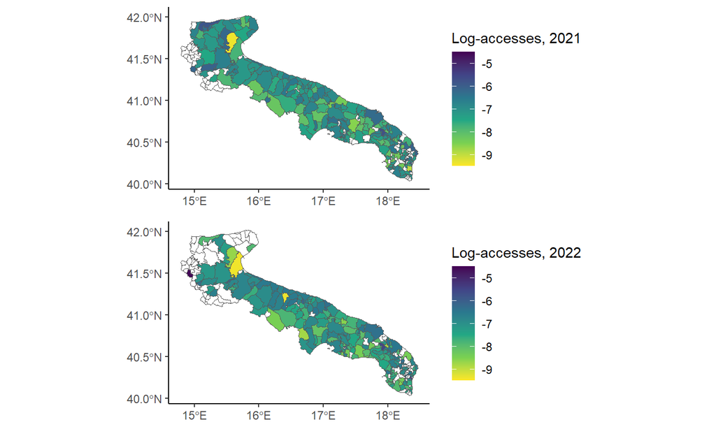

Log-access rate, 2021-2022

## Access to AVCs in Apulia: Incidence (II)

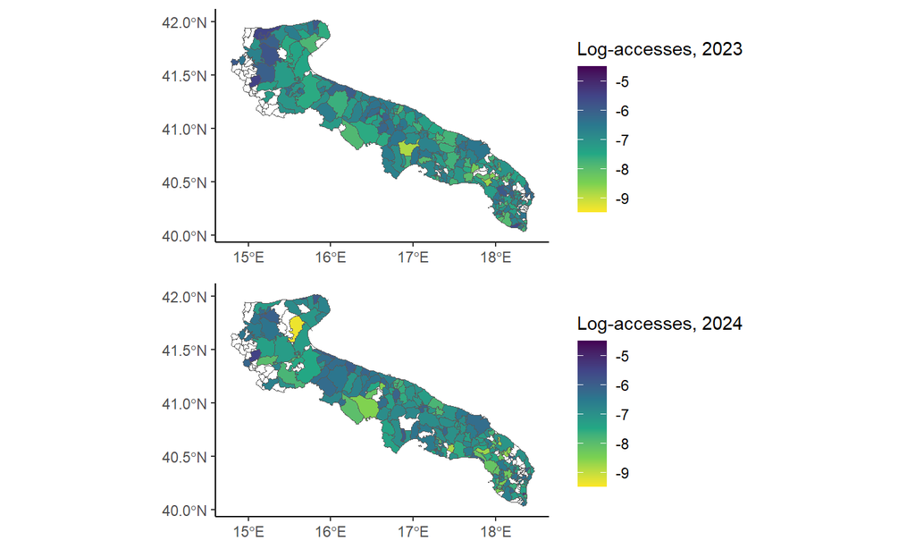

Log-access rate, 2023-2024

## Explanatory variables

- **Distance** (`TEP`) from the **closest municipality** hosting an AVC
- Components of the **Municipality Frailty Index** (MFI), 2021; source: [ISTAT](https://www.istat.it/comunicato-stampa/indice-di-fragilita-comunale-ifc/)

| Variable | Unit | Description |
| --- | --- | --- |
| TEP | Minutes | Road **travel time** to the **closest** municipality hosting an AVC |
| ELI | Ventile | Share of employees in **low productivity** units |
| PGR | Rate | **Population growth** rate 2011–2021 |
| UIS | Ventile | **Density** of **economic** production units |
| ELL | Percentage | Population aged [25–64] with **low education** level |
| PDI | Percentage | **Structural dependency** index (population aged [0–19] or >64 over [20–64]) |
| ER | Percentage | **Employment rate** among population aged [20–64] |

## Regression model

- **256** municipalities, **4** years
- Standard **Poisson** linear regression: for \(i \in [1,256]\), and \(t \in [2021, 2024]\) we have

\[ y_{it}\mid \eta_{it}, \theta \sim \mathrm{Poisson} \left( \mathrm{E}_{it} \, e^{\eta_{it}} \right) \]

- Where
  - \(y_{it}\): AVC accesses in municipality \(i\) and year \(t\);
  - \(\mathrm{E}_{it}\): female population aged \(>14\) years (offset)
  - \(\eta_{it}\): linear predictor; \(\theta\): model hyperparameters

## The linear predictor

- Inclusion of a multivariate latent **spatial** effect in \(\eta\) to account for **territorial variability** and **overdispersion**

\[\eta_{it} := X_{it}^\top \beta + Z_{it}\] - \(X\): Covariates; \(\beta\): covariate effects

- \(Z_{it}\): multivariate latent spatial effect of size \(n \times k\), where \(n=256\) and \(k=4 \quad \longrightarrow\) modelled via the flexible **M-Models** (Botella-Rocamora, Martinez-Beneito, and Banerjee 2015)
- Competing models: **ICAR**, **PCAR**, **LCAR** and **BYM**

## Models (I): Intrinsic CAR

- Simplest formulation among spatial autoregressive models

\[ Z \mid \Sigma \sim \mathcal{N}_{kn} \left( 0, \Sigma \otimes (D - W)^{+} \right) \]

- \(\Sigma\): \(4 \times 4\) between-fields variance-covariance matrix
- \(D\): Graph **degree** matrix;
- \(W\): Graph **neighbourhood** matrix

\(+\) Easy to **fit** and **interpret**

\(-\) implicitly assumes **spatial autocorrelation** equal to 1 \(\rightarrow\) sometimes too **smooth** to adequately fit data

## M-models (I)

- Based on the **decomposition** of the **variance-covariance** matrix as \(\Sigma := M^\top M\)
- \(M\): **full** rank matrix, of size \(k \times k\) herein
- consider \(Z\) as a **combination** of \(k\) independent fields \(Z_j^{(0)}\) for \(1 \leq j \leq k\), i.e. \(Z := \left(Z_1^{(0)}, \dots, Z_k^{(0)}\right) M\)
- \(Z^{(0)} \sim \mathcal{N}_n \left( 0, \Omega_j \right)\) for a \(n \times n\) s.p.d. matrix \(\Omega_j\) depending:
  - On the **graph** structure
  - On an array of **model-specific** parameters

## M-models (II)

Joint prior of \(Z\):

\[ Z \sim \mathcal{N}_{nk} \left(0, (M^\top\otimes I_n)\, \Omega \, (M \otimes I_n) \right) \] Where \(\Omega\) is block-diagonal: \[ \Omega = \begin{pmatrix} \Omega_1 & 0 & \dots & 0 \\ 0 & \Omega_2 & \dots & 0 \\ \vdots & \vdots & \ddots & \vdots \\ 0 & 0 & \dots & \Omega_k \end{pmatrix} \]

- Three **standard** models for \(\Omega\) compared in next slides

## Models (II): Proper CAR (PCAR)

- Generalises the ICAR allowing for a **proper** prior density with **nonsingular** precision (Gelfand and Vounatsou 2003)
- Introduces a **spatial correlation** parameter \(A := \mathrm{diag}(\alpha_1, ... \alpha_k)\), \(\alpha_j \in [0,1] \, \forall j\)

\[ \Omega = (I_k \otimes D - A \otimes W)^{-1} \]

- **Limit** cases:
  - \(\alpha_t = 0\): **independent** model (\(\neq\) IID)
  - \(\alpha_t = 1\): **ICAR**

## Models (III): Leroux proper CAR (LCAR)

- Also generalises the ICAR allowing for a **proper** density
- Introduces a **precision mixing** parameter \(\Lambda := \mathrm{diag}(\lambda_1, ... \lambda_k)\), yet with \(\lambda_j \in [0,1] \, \forall j\) (Leroux, Lei, and Breslow 2000)

\[ \Omega_j = \left(\Lambda \otimes L + (I_k - \Lambda) \otimes I_n \right)^{-1} \] - \(L\) = graph **Laplacian** matrix, i.e. \(L = D-W\)

- Limit cases:
  - \(\lambda_t = 0\): IID model
  - \(\lambda_t = 1\): ICAR

## Models (IV): Besag-York-Mollié (BYM)

- Actually a **reparametrisation** of the original BYM (Besag, York, and Mollié 1991), proposed by (Riebler et al. 2016)

\[ Z = U \Phi^\frac{1}{2} M + V (I_k-\Phi^\frac{1}{2}) M \]

- \(U \sim \mathcal{N}_{kn} \left(0, I_k \otimes L_S^{+} \right)\): independent ICAR (limit case for \(\Phi = I_k\)) \(\rightarrow\) **spatial dependence**, where \(L_S\): **scaled** Laplacian (Riebler et al. 2016)
- \(V \sim \mathcal{N}_{kn} (0, I_{kn})\): IID field (limit case for \(\Phi = 0\)) \(\rightarrow\) **noise**
- \(\Phi := \mathrm{diag}(\phi_1, \dots, \phi_k)\): **variance** mixing parameter, \(\phi_j \in [0, 1]\, \forall j\)

## Multivariate PC-prior

- The parameters \(A\), \(\Lambda\) and \(\Phi\) are usually assigned a **Uniform** prior
- A more **principle-based** approach is using **PC-priors**
  - This was already done by Rieber et al. (2016) for the **univariate** BYM
- Question: can we apply this approach in the **multivariate** setting, and also for **PCAR** and **LCAR** models?
- Caveat: deriving **analytically** a PC-prior for **multivariate** parameters is hardly possible (Simpson et al. 2017), (Battagliese 2020) \(\longrightarrow\) workaround: **Sequential** derivation

## PC priors: principles

**Penalise** the **departure** of a model depending on a parameter \(\theta\) from a **simpler** (base) one (Simpson et al. 2017):

- **Simple** model: here, an **independent**, unstructured one, with \(\theta = 0\)
- **Departure**: a measure of how the more **flexible** model, say \(\mathcal{M}_F\) **diverges** from the **simple** one, say \(\mathcal{M}_B \rightarrow\) **distance** function: \(d (\mathcal{M}_F||\mathcal{M}_B) := \sqrt{2 \mathrm{KLD}(\mathcal{M}_F||\mathcal{M}_B)}\)
- **Penalise**: shrink the p.d.f. of \(d(\mathcal{M}_F||\mathcal{M}_B)\) at a constant rate \(\rightarrow\) **exponential** prior on \(d\)

Fix two parameters \(\theta_0, \mathcal{a}:\mathrm{Prob} \lbrace \theta \leq \theta_0 \rbrace = \mathcal{a}\)

## A Sequential approach for the PC-prior

- Let \(\theta_j\) denote either \(\alpha_j\), \(\lambda_j\), or \(\phi_j\) for \(j = 1, \dots, k\)
- At each **step** \(j\), we test the **flexible** model with \(\theta_j > 0\), against the **base** model with \(\theta_j = 0\), all other parameters being **unchanged**
- Then, the **joint** prior simply comes from the chain rule:

\[\pi(\theta) = \pi (\theta_1) \pi(\theta_2 \mid \theta_1) \dots \pi(\theta_k \mid \theta_1, \dots, \theta_{k-1})\]

- Provided that

\[ \begin{align*} \pi(\theta_j \mid \theta_1, \dots, \theta_{j-1}) = \\ =\pi(\theta_j \mid \theta_1, \dots, \theta_{j-1}, \theta_{j+1}=\dots=\theta_k=0) \end{align*} \]

## PC priors: ractical findings

- PC-priors available in **closed formula**
- \(\pi(\theta)\) independent on \(\Sigma\)
- \(\pi(\theta_j \mid \theta_1, \dots, \theta_{j-1}) = \pi(\theta_j)\), i.e., at each step \(j\), the prior of \(\theta_j\) is independent on other parameters

\[ \therefore \pi(\theta) = \prod_{j=1}^k \pi(\theta_j) \]

- Only needed **Laplacian** eigenvalues (LCAR, BYM) or eigenvalues of \(D^{-1}W\) (PCAR), both **deterministic** \(\rightarrow\) computed **once**

## Univariate PCAR PC-prior

[figure not shown]

- Prior based on a regular lattice
- Three examples for bound \(\theta_0\): 0.4, 0.5, 0.6
- Increasing tail probability \(\mathcal{a} > \theta_0\)

## Univariate LCAR PC-prior

[figure not shown]

- Prior based on a regular lattice
- Three examples for bound \(\theta_0\): 0.5, 0.6, 0.7
- Increasing tail probability \(\mathcal{a} > \theta_0\)
- Maybe better to work with **high** bound values and very high tail probabilities

## Univariate BYM PC-prior

[figure not shown]

- As in Riebler et al. (2016)

Prior based on a regular lattice

- Three examples for bound \(\theta_0\): 0.4, 0.5, 0.6
- Increasing tail probability \(\mathcal{a} > \theta_0\)

## Model diagnostics

Models compared by the WAIC – **Watanabe–Akaike** Information Criterion (Gelman, Hwang, and Vehtari 2014). Free parameters are reported as well.

|  | Model | WAIC | P_WAIC |
| --- | --- | --- | --- |
| 1 | Nosp | 4798.74 | 44.5 |
| 2 | ICAR | 3892.65 | 260.08 |
| 3 | PCAR_Un | 3891.44 | 264 |
| 4 | PCAR_PC | 3890.62 | 266.12 |
| 5 | LCAR_Un | 3903.43 | 266.45 |
| 6 | LCAR_PC | 3874.69 | 259.82 |
| 7 | BYM_Un | 3864.97 | 255.94 |
| 8 | BYM_PC | 3863.86 | 254.06 |

## Model prior choice - BYM

- **Covariate** effects: independent weekly informative Gaussians \(\mathcal{N}(0, 10^3)\)
- \(\Sigma\): **Wishart** prior, with **identity** scale parameter *and* 8 **degrees of freedom**
- \(\Phi\): PC-prior, with \(\mathrm{Prob} \lbrace \phi_j \leq 0.6 \rbrace = 0.9\) for all \(j\)
- Model estimation is carried out entirely within **R-INLA** (Rue, Martino, and Chopin 2009) using the **Variational Bayes** (Van Niekerk et al. 2023) correction to the posterior mean of latent variables

## Covariate effect posterior

|  | Effect | Mean | Sd | Q_0.025 | Q_0.975 |
| --- | --- | --- | --- | --- | --- |
| Y_2021 | Y_2021 | -7.437 | 0.049 | -7.533 | -7.341 |
| Y_2022 | Y_2022 | -7.616 | 0.06 | -7.735 | -7.501 |
| Y_2023 | Y_2023 | -7.197 | 0.047 | -7.29 | -7.104 |
| Y_2024 | Y_2024 | -7.332 | 0.053 | -7.437 | -7.228 |
| TEP_th | TEP_th | -0.21 | 0.045 | -0.298 | -0.123 |
| ELI | ELI | -0.002 | 0.04 | -0.079 | 0.076 |
| PGR | PGR | 0.076 | 0.043 | -0.009 | 0.161 |
| UIS | UIS | 0.084 | 0.041 | 0.004 | 0.165 |
| ELL | ELL | -0.22 | 0.052 | -0.321 | -0.119 |
| PDI | PDI | -0.035 | 0.047 | -0.127 | 0.056 |

[output cut: 1 more lines]

## Covariate Effects Interpretation

\(y =\) VAW **occurrence** \(\times\) incidents **reporting** rate

- **Twofold interpretation** of covariate **effects** on AVC **accesses**
- **TEP**: either relative ease in reporting violence in **proximity** of AVCs, or **appropriateness** of AVC **placement**
- **ELL**: lower **reliance** on AVCs in **poor education** contexts
- **ER**: lower violence **occurrence** in more **developed** areas

## Hyperparameter posterior (I)

- Posterior distribution of the **mixing** parameter (\(\Phi\))
- Percentage of **variation** explained by **spatial dependence**

|  | Year | Mean | Q_0.025 | Median | Q_0.975 |
| --- | --- | --- | --- | --- | --- |
| 1 | 2021 | 0.534 | 0.454 | 0.5315 | 0.623 |
| 2 | 2022 | 0.679 | 0.603 | 0.68 | 0.751 |
| 3 | 2023 | 0.231 | 0.216 | 0.2302 | 0.249 |
| 4 | 2024 | 0.729 | 0.674 | 0.7294 | 0.782 |

## Hyperparameter posterior (II)

- Posterior of the **variance-covariance** matrix (\(\Sigma\))

|  | Year | Mean | Q_0.025 | Median | Q_0.975 |
| --- | --- | --- | --- | --- | --- |
| 1 | Var_2021 | 0.31 | 0.169 | 0.2954 | 0.533 |
| 2 | Var_2022 | 0.529 | 0.308 | 0.5202 | 0.804 |
| 3 | Var_2023 | 0.351 | 0.254 | 0.3453 | 0.475 |
| 4 | Var_2024 | 0.493 | 0.393 | 0.4889 | 0.616 |
| 5 | Corr_2021/22 | 0.732 | 0.65 | 0.7351 | 0.797 |
| 6 | Corr_2021/23 | 0.326 | 0.085 | 0.3315 | 0.526 |
| 7 | Corr_2021/24 | 0.403 | 0.259 | 0.4034 | 0.538 |
| 8 | Corr_2022/23 | 0.115 | -0.232 | 0.1191 | 0.435 |
| 9 | Corr_2022/24 | 0.166 | -0.091 | 0.1723 | 0.395 |
| 10 | Corr_2023/24 | 0.772 | 0.696 | 0.7747 | 0.831 |

## Expected latent effect - BYM

Posterior values of \(\mathbb{E}[Z \mid y]\)

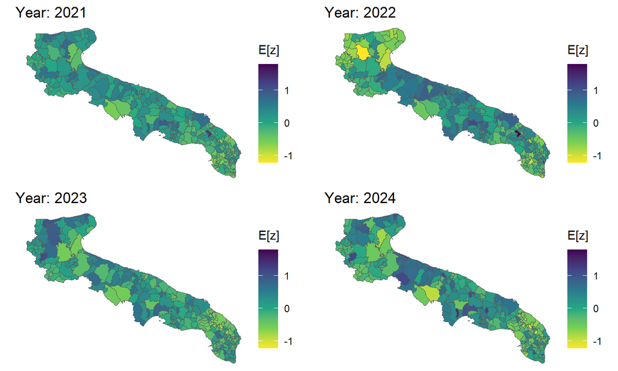

## Possible development directions

**Intepretation** and modelling:

- Separate **factors** driving the two processes of **violence occurring** and **help seeking**

  \(\longrightarrow\) allocate **covariates** between two **separate** predictors: i.e. **Poisson–Logistic** regression (Stoner, Economou, and Silva 2019), (Polettini, Arima, and Martino 2024)

Statistical **methodology**:

- More insight on **PC prior** behaviour in PCAR and LCAR models \(\longrightarrow\) **simulation** analysis
- Extend the **PC-prior** approach to the **correlation** matrix (Freni-Sterrantino et al. 2025)

## Cited works

Battagliese, Diego. 2020. “Extensions of the Univariate PC Prior.” *Annali Del Dipartimento Di Metodi e Modelli Per l’Economia, Il Territorio e La Finanza (MEMOTEF)*, 33–46. https://doi.org/https://doi.org/10.13133/2611-6634/509.

Besag, Julian, Jeremy York, and Annie Mollié. 1991. “Bayesian Image Restoration, with Two Applications in Spatial Statistics.” *Annals of the Institute of Statistical Mathematics* 43 (1): 1–20.

Botella-Rocamora, Paloma, Miguel A Martinez-Beneito, and Sudipto Banerjee. 2015. “A Unifying Modeling Framework for Highly Multivariate Disease Mapping.” *Statistics in Medicine* 34 (9): 1548–59.

Freni-Sterrantino, Anna, Denis Rustand, Janet van Niekerk, Elias Teixeira Krainski, and Håvard Rue. 2025. “A Graphical Framework for Interpretable Correlation Matrix Models for Multivariate Regression: A. Freni-Sterrantino Et Al.” *Statistical Methods & Applications*, 1–39.

Gelfand, A. E., and P. Vounatsou. 2003. “Proper Multivariate Conditional Autoregressive Models for Spatial Data Analysis.” *Biostatistics* 4 (1): 11–15. https://doi.org/https://doi.org/10.1093/biostatistics/4.1.11.

Gelman, Andrew, Jessica Hwang, and Aki Vehtari. 2014. “Understanding Predictive Information Criteria for Bayesian Models.” *Statistics and Computing* 24 (6): 997–1016. https://doi.org/10.1007/S11222-013-9416-2.

Leroux, Brian G., Xingye Lei, and Norman Breslow. 2000. “Estimation of Disease Rates in Small Areas: A New Mixed Model for Spatial Dependence.” In *Statistical Models in Epidemiology, the Environment, and Clinical Trials*, edited by M. Elizabeth Halloran and Donald Berry, 179–91. New York, NY: Springer New York. https://doi.org/https://doi.org/10.1007/978-1-4612-1284-3_4.

Polettini, Silvia, Serena Arima, and Sara Martino. 2024. “An Investigation of Models for Under-Reporting in the Analysis of Violence Against Women in Italy.” *Social Indicators Research* 175 (3): 1007–26.

Riebler, Andrea, Sigrunn H Sørbye, Daniel Simpson, and Håvard Rue. 2016. “An Intuitive Bayesian Spatial Model for Disease Mapping That Accounts for Scaling.” *Statistical Methods in Medical Research* 25 (4): 1145–65.

Rue, Haavard, Sara Martino, and Nicholas Chopin. 2009. “Approximate Bayesian Inference for Latent Gaussian Models by Using Integrated Nested Laplace Approximations.” *Journal of the Royal Statistical Society Series B: (Methodological)* 71 (2): 319–92. https://doi.org/10.1111/j.1467-9868.2008.00700.x.

Simpson, Daniel, Haavard Rue, Andrea Riebler, Thiago G. Martins, and Sigrunn H. Sørbye. 2017. “Penalising Model Component Complexity: A Principled, Practical Approach to Constructing Priors.” *Statistical Science* 32 (1): 1–28. https://doi.org/10.1214/16-STS576.

Stoner, Oliver, Theo Economou, and Gabriela Drummond Marques da Silva. 2019. “A Hierarchical Framework for Correcting Under-Reporting in Count Data.” *Journal of the American Statistical Association*.

Van Niekerk, Janet, Elias Krainski, Denis Rustand, and Haavard Rue. 2023. “A New Avenue for Bayesian Inference with INLA.” *Computational Statistics and Data Analysis* 181. https://doi.org/10.1016/j.csda.2023.107692.